# Missing Values

- Show All Code
- Hide All Code
- View Source

Author

Diego Pinto

# Dealing with missing values

```r
setwd("~/Desktop/R_projects/msc")


rm(list = ls()) # Clear Global Environment

library(tidyverse)
library(naniar)
library("mice") #for multiple imputation
```

```r
data <- read_csv("data/middle_school_music_mindsets_clean_2_careless_removed.csv")
```

## Analyzing missing values

### What is the ratio of missing values in the entire dataset?

```r
missing_sum <- sum(is.na(data)) #sum of all missing values

data_points_count <- nrow(data) * ncol(data) #number of datapoints in the datafrae

missing_percentage <- missing_sum /data_points_count #percentage of all missing values

print(missing_percentage)
```

```
[1] 0.03018648
```

The dataset contained 1036 missing data points, which corresponds to 3.02% of the entire data set.

### What section of the survey contains the most missing values?

#### Save section of survey into separate dataframes for following calculations:

```r
data_demographic <- data %>%
  select(survey_id:currentSchoolMusic) #demographic variables, except currentSchoolMusic_other

s1 <- data %>%
  select(matches("s1")) #section 1 (Likert 1-4)

s2 <- data %>%
  select(matches("s2")) #section 2 (Likert 1-7, mostly)

s3 <- data %>%
  select(matches("s3")) #section 3 (Likert 1-4)

measures_data <- data %>%
  select(s1_1:s3_28) %>%
  select_if(is.numeric) #sections 1, 2, and 3 combined, excluding variables with character data (i.e., instrument_play_best).

#data_family_subset <- filter(data, is.na(data$s2_8))

#survey_id <- data$survey_id
```

#### Calculate missing values per survey section

```r
#missing values in demographic questions
demographics_missing_rate <- (sum(is.na.data.frame(data_demographic))) / (nrow(data_demographic) * ncol(data_demographic))

#missing values in sections 1
s1_missing_rate <- (sum(is.na.data.frame(s1))) / (nrow(s1) * ncol(s1))

#missing values in section 2 (s21_:s2)
s2_missing_rate <- (sum(is.na.data.frame(s2))) / (nrow(s2) * ncol(s2))

#missing values in sections 3
s3_missing_rate <- (sum(is.na.data.frame(s3))) / (nrow(s3) * ncol(s3))
```

The rate of missing data per survey section was as follow:

• Demographics: 3.48%

• Section 1: 1.06%

• Section 2: 0.88%

• Section 3: 1.75%

The demographic section has highest rate of missing values. Still, that rate is below 5%.

### What is the rate of missing values per item?

```r
#Calculate is.na for each item. Add results to new dataframe

missing_per_item <- sapply(data, function(x) sum(is.na(x)))

missing_per_item_df <- data.frame(missing_count = missing_per_item,
                                  missing_rate = round(missing_per_item/ nrow(data),2))

select(missing_per_item_df, missing_rate)
```

```
                         missing_rate
survey_id                        0.00
grade                            0.01
age                              0.21
school                           0.00
race                             0.01
hispanic_latino                  0.03
gender                           0.01
currentSchoolMusic               0.01
currentSchoolMusic_other         0.96
s1_1                             0.01
s1_2                             0.01
s1_3                             0.01
s1_4                             0.01
s1_5                             0.01
s1_6                             0.01
s1_7                             0.01
s1_8                             0.01
s1_9                             0.01
s1_10                            0.02
s1_11                            0.01
s1_12                            0.01
s1_13                            0.01
s2_1                             0.01
s2_2                             0.01
s2_3                             0.01
s2_4                             0.02
s2_5                             0.00
s2_6                             0.01
instrument                       0.00
familyMusic                      0.00
schoolChoir                      0.01
schoolInstrumental               0.00
schoolExtracurricular            0.00
outsideChoir                     0.00
outsideInstrumental              0.01
privateLesson                    0.01
selfTaught                       0.01
s3_1                             0.02
s3_2                             0.01
```

[output cut: 11 more lines]

```
s3_14                            0.02
s3_15                            0.02
s3_16                            0.02
s3_17                            0.02
s3_18                            0.02
s3_19                            0.01
s3_20                            0.02
s3_21                            0.01
s3_22                            0.02
s3_23                            0.02
s3_24                            0.02
s3_25                            0.03
s3_26                            0.02
s3_27                            0.03
s3_28                            0.02
```

Most relevant items (e.g., mindets, msc, and other psychometric measures) had low rate of missing values (<- 4%). Excluding items was not necessary. Because “age” had a high number of missing values (21.00%), I will not include that variable in the data analysis (except for descriptive analysis).

Because currentSchoolMusic_other column only applies to students who selected taking “another music class” besides band, choir, or orchestra, most participants did not fill that blank and, thus, most NA are not missing data. Moreover, “age” had a high rate of missing values. To facilitate imputation, I will only use variables with missing values rate below 5%. Therefore, I removed “age” and “currentSchoolMusic_other from the dataset.

```r
data <- data %>%
  select(-age, -currentSchoolMusic_other)
```

### How many observations do not contain missing values and how many do (after removing careless responses)?

```r
complete_cases <- sum(complete.cases(data))

print(complete_cases)
```

```
[1] 395
```

```r
incomplete_cases <- sum(!complete.cases(data))

print(incomplete_cases)
```

```
[1] 133
```

After removing observation with potential careless responding, 395 observation did not contain missing values in any variable.

Although data are missing in 25.19% of observations, there are some outliers with rates of missing data much higher than most, as seen in the chart below:

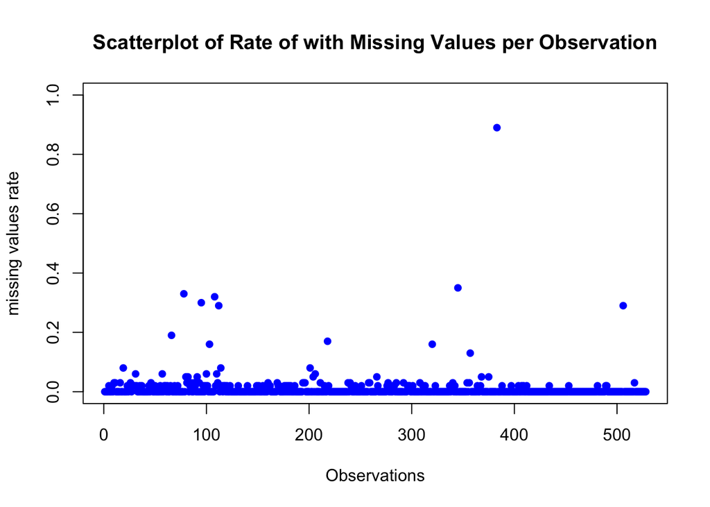

```r
# Calculate is.na for each observatoin. Add results to new dataframe.
missing_per_obs_df <- data %>%
  mutate(across(everything(), as.character)) %>%
  rowwise() %>%
  summarize(
    survey_id,
    missing_count = sum(is.na(c_across(everything()))),
    missing_rate = round(missing_count / ncol(data), 2),)

#View scatterplot to visually identify outliers
plot(missing_per_obs_df$missing_rate, main = "Scatterplot of Rate of with Missing Values per Observation", xlab = "Observations", ylab = "missing values rate", pch = 16, col = "blue", ylim = c(0, 1))
```

#### Flag observations with high rate of missing values.

To address those outliers, I flagged observations in which missing data accounted for more than 40% of the responses.

```r
#Create dataframe with observations containing 10%+ of missing values
missing_per_obs_high <- missing_per_obs_df %>%
  filter(missing_rate > .4)

#Save flagged observations to vector
flagged_obs <- as.numeric(missing_per_obs_high$survey_id)

print(flagged_obs)
```

```
[1] 482
```

```r
flagged_obs_df <- data %>%
  filter(survey_id %in% flagged_obs)
```

During this step, only observations 1 were flagged.

## Removing or Imputing Observations

#### Remove surveys with high rate of missing values

```r
sum(!is.na(flagged_obs)) # number of observations removed
```

```
[1] 1
```

```r
data <- data %>%
  filter(!survey_id %in% flagged_obs) #keep only observations not flagged due to high rate of missing data

dim(data) #New dimension of dataset after flagged observations removed
```

```
[1] 527  63
```

Based on the rate of missing data per observation (above 40%)), I removed 1 observations from the dataset.

### Little’s (1988) Test of Missingness

I calculated Little’s Test of Missing to determine the nature of missing data (i.e., MCAR, MAR, MNAR), thus suggesting whether manipulating missing data (deleting or imputing) in the remainder of the dataset would significantly affect data analysis. The following are Little’s test’s hypotheses:

H0: Data is missing completely at random (MCAR)

H1: Data is missing at random (MAR)

H2: Data is missing not a random (MNAR)

```r
mcar_test <- mcar_test(data)
print(mcar_test)
```

```
# A tibble: 1 × 4
  statistic    df p.value missing.patterns
      <dbl> <dbl>   <dbl>            <int>
1     1831.  5487       1               93
```

Based on the results from Little’s Test of Missingness, we fail to reject the null hypothesis. Hence, missing values are likely missing completely at random (MCAR), and data imputation should not significantly alter the results.

## Multiple Imputation by Chained Equations

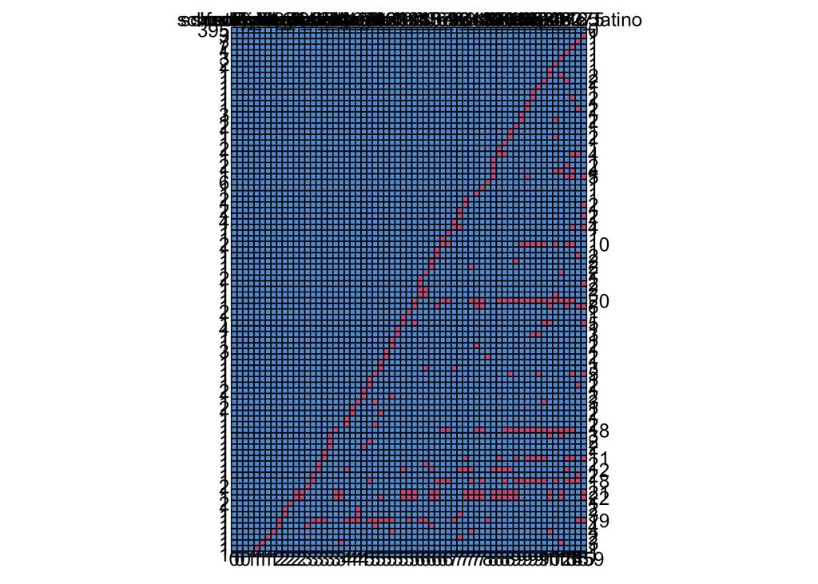

```
    survey_id school instrument s2_5 familyMusic schoolInstrumental
395         1      1          1    1           1                  1
3           1      1          1    1           1                  1
7           1      1          1    1           1                  1
2           1      1          1    1           1                  1
1           1      1          1    1           1                  1
3           1      1          1    1           1                  1
2           1      1          1    1           1                  1
1           1      1          1    1           1                  1
1           1      1          1    1           1                  1
1           1      1          1    1           1                  1
1           1      1          1    1           1                  1
1           1      1          1    1           1                  1
1           1      1          1    1           1                  1
1           1      1          1    1           1                  1
```

[output cut: 657 more lines]

```r
md.pattern(data)
```

```r
imputed_data <- mice(data, m = 5, method = "rf")
summary(imputed_data)
```

```
Class: mids
Number of multiple imputations:  5
Imputation methods:
            survey_id                 grade                school
                   ""                  "rf"                    ""
                 race       hispanic_latino                gender
                   ""                    ""                    ""
   currentSchoolMusic                  s1_1                  s1_2
                   ""                  "rf"                  "rf"
                 s1_3                  s1_4                  s1_5
                 "rf"                  "rf"                  "rf"
                 s1_6                  s1_7                  s1_8
                 "rf"                  "rf"                  "rf"
                 s1_9                 s1_10                 s1_11
                 "rf"                  "rf"                  "rf"
                s1_12                 s1_13                  s2_1
                 "rf"                  "rf"                  "rf"
                 s2_2                  s2_3                  s2_4
                 "rf"                  "rf"                  "rf"
                 s2_5                  s2_6            instrument
                 "rf"                  "rf"                    ""
          familyMusic           schoolChoir    schoolInstrumental
                   ""                  "rf"                  "rf"
schoolExtracurricular          outsideChoir   outsideInstrumental
                 "rf"                  "rf"                  "rf"
        privateLesson            selfTaught                  s3_1
                 "rf"                  "rf"                  "rf"
                 s3_2                  s3_3                  s3_4
                 "rf"                  "rf"                  "rf"
                 s3_5                  s3_6                  s3_7
                 "rf"                  "rf"                  "rf"
                 s3_8                  s3_9                 s3_10
                 "rf"                  "rf"                  "rf"
                s3_11                 s3_12                 s3_13
                 "rf"                  "rf"                  "rf"
                s3_14                 s3_15                 s3_16
                 "rf"                  "rf"                  "rf"
                s3_17                 s3_18                 s3_19
                 "rf"                  "rf"                  "rf"
                s3_20                 s3_21                 s3_22
```

[output cut: 55 more lines]

```
                s3_19 s3_20 s3_21 s3_22 s3_23 s3_24 s3_25 s3_26 s3_27 s3_28
survey_id           1     1     1     1     1     1     1     1     1     1
grade               1     1     1     1     1     1     1     1     1     1
school              1     1     1     1     1     1     1     1     1     1
race                0     0     0     0     0     0     0     0     0     0
hispanic_latino     0     0     0     0     0     0     0     0     0     0
gender              0     0     0     0     0     0     0     0     0     0
Number of logged events:  7
  it im dep     meth                out
1  0  0     constant             school
2  0  0     constant               race
3  0  0     constant    hispanic_latino
4  0  0     constant             gender
5  0  0     constant currentSchoolMusic
6  0  0     constant         instrument
```

```r
imputed_dataset <- complete(imputed_data)

#Update number of complete and incomplete cases

complete_cases <- sum(complete.cases(imputed_dataset))

print(complete_cases)
```

```
[1] 503
```

```r
incomplete_cases <- sum(!complete.cases(imputed_dataset))

print(incomplete_cases)
```

```
[1] 24
```

```r
imputed_dataset <- imputed_dataset %>%
filter(complete.cases(imputed_dataset))
```

After imputing data using the “mice” function the number of complete cases increased to 503, and 24 observations still contained missing data. Hence, I removed those observations from the data set.

```r
write_csv(imputed_dataset, "data/middle_school_music_mindsets_clean_3_imputed.csv")
```